# cs625-HW2

# Part 1: Data Cleaning

## Cleaning using GREL Statements:

1. First of all in the column “What kind of pet it is”, we can see pet name “Dog” occurring in different spelling as shown below:-

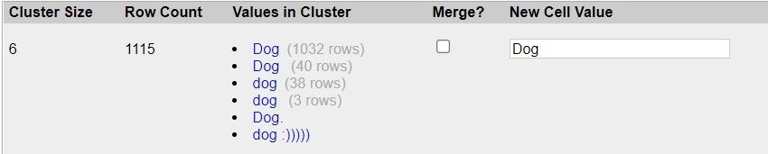

- This can be replaced by following GREL Statement:-
- value.replace(“Dig”,“Dog”).replace(“dig”,“Dog”).replace(“Doggo”,“Dog”).replace(“God”,“Dog”).replace(“Pit bull”,“Dog”).replace(“Puppy”,“Dog”).replace(“Sog”,“Dog”).replace(“dig”,“Dog”).replace(“dlg”,“Dog”)
- Similarly there are lots of redundant entries falling into the same category, so we can replace them just as we did above:-

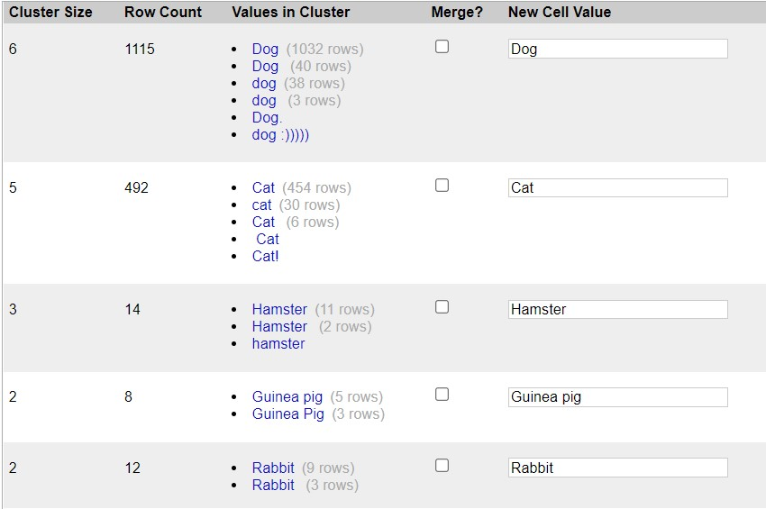

- value.replace(“cat”,“Cat”).replace(“Cat!”,“Cat”)
- value.replace(“hamster”,“Hamster”)
- value.replace(“Guinea pig”,“Guinea Pig”)
- value.replace(“bunny”,“Bunny”)
- value.replace(“Hermit crab”,“Hermit Crab”)
- value.replace(” Cat”,“Cat”)
- value.replace(“Cats”,“Cat”)
- value.replace(“Kitty Meow”,“Cat”).replace(“Kitten”,“Cat”)
- value.replace(“Dog :)))))”,“Dog”)
- value.replace(“Beta fish”,“Betta fish”)
2. There is a category termed as “Other” as shown below:-

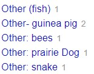

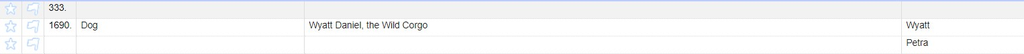

- Now to remove them here is what I did:
- From the drop down menu of that column click “Facet” then click on “Customized Facets”.
- After that click on “Facet by blank(null or empty string)”.
- After doing this click on true from the facet menu appear at left side.

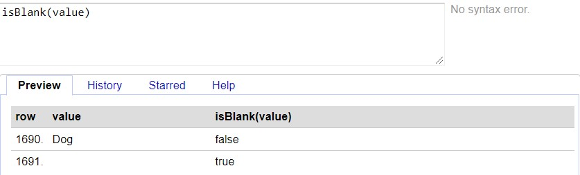

- Finally click on drop down menu of “All->Edit rows->Remove matching rows”.

## Manual Editing:-

1. For “What kind of pet it is” column:-
- After performing above mentioned steps, the clusters look like this:-

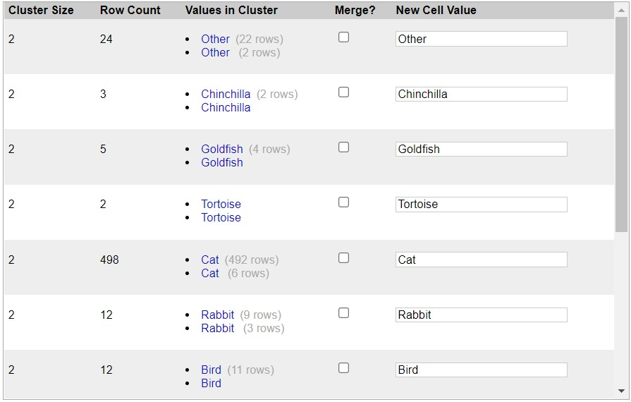

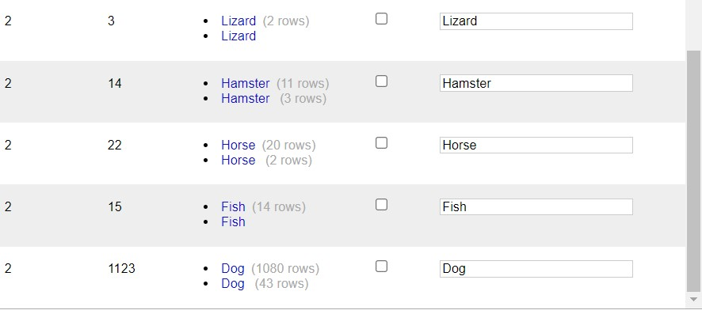

- Then I have merged this clusters by going to the drop down menu, Edit cells->Cluster and edit->Merge Selected & Re-cluster.
- There were multiple entries in same cell as shown below:-

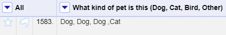

- To seperate them:-
  - Edit cell->split multi valued cells-> by seperator(mention “,” as seperator)->ok

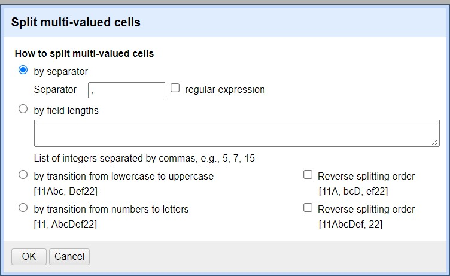

2. For “Pet’s Breed” column:-
- Below you can see the redundant entries that contains spelling errors:-

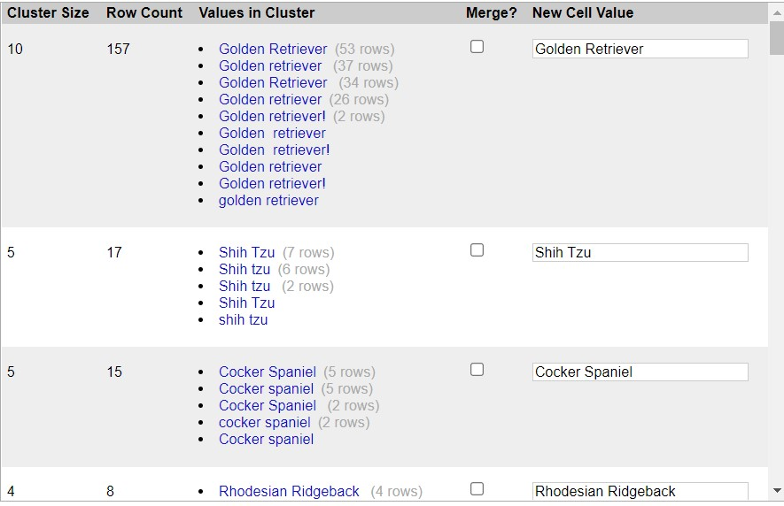

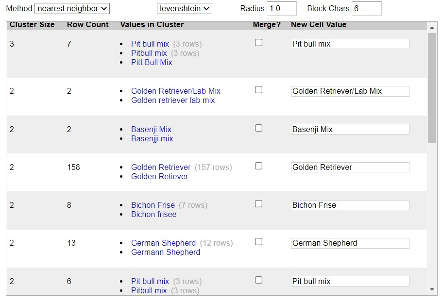

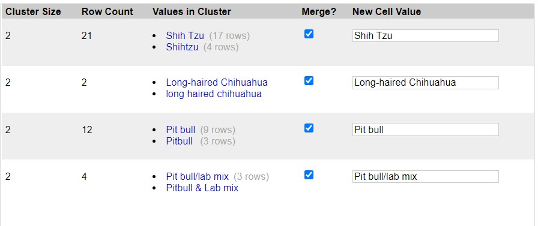

- I have merged them together using Cluster and Edit feature of column just as mentioned above in step 1.
- Also I have tried different methods,i.e.”key collision” and “nearest neighbor” and different keying functions to merge the clusters.
3. For “Pet’s Age” column:-
- I performed “Edit cells->Common transforms->To number”
- There were redundant entries as shown below:-

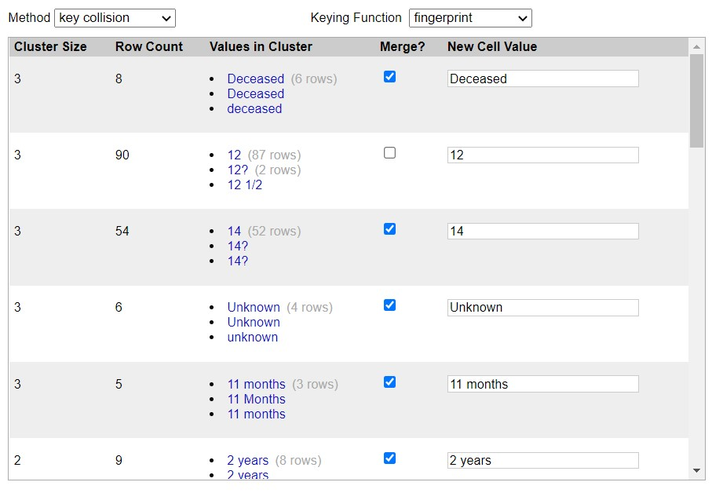

- I get rid of them and re-clustered by applying Cluster and Edit feature.
4. For “Pet’s Full Name” column:-
- The same redundancy is seen here:-

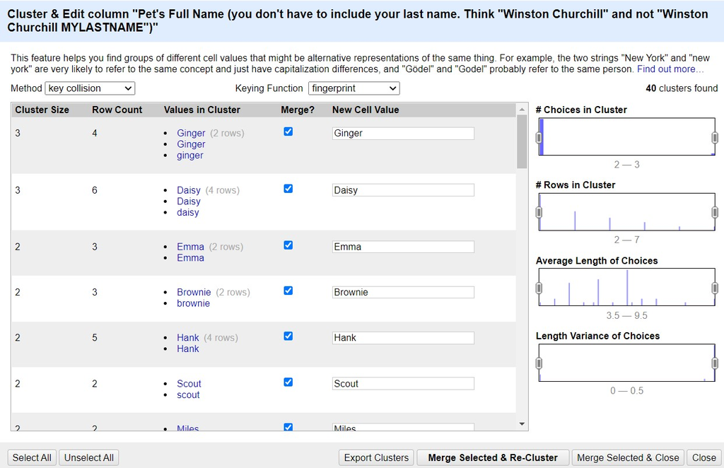

- To get rid of it I applied Cluster and Edit feature and re-clustered them.

# Part 2:- Analyze Cleaned Data

1. How many types (kinds) of pets are there?
   - 36
2. How many dogs?
   - 1123
3. How many breeds of dogs?
   - 399(exclucing blank entries)
4. What’s the most popular dog breed?
   - Golden Retriever
5. What’s the age range of the dogs?
   - 6 week to 30
6. What’s the age range of the guinea pigs?
   - 1 to 5
7. What is the oldest pet?
   - Dog
8. Which are more popular, betta fish or goldfish? How many of each?
   - Goldfish is popular. Goldfish:5, Betta Fish: 2
9. What’s the most popular everyday name for a cat?
   - Kitty
10. What’s the most popular full name for a dog?
- Maggie

# References

1. https://wordpress.com/support/markdown-quick-reference/
2. https://docs.openrefine.org/manual/grelfunctions#splits-s-or-p-sep-b-preservetokens-optional
3. https://webscraper.io/blog/data-transformation-with-Open-Refine
4. http://www.morgancurrie.com/wp-content/uploads/2016/12/Open_Refine_Tut2.pdf
5. https://datacarpentry.org/openrefine-socialsci/04-numbers/
6. https://stackoverflow.com/questions/24840767/filter-only-by-having-blank-empty-string-cells/24841276#24841276
7. https://guides.library.illinois.edu/openrefine/splitting